# Shiny Workshop: Day 1

### Contents

Click to view a specific section of the document.

- 1.1 Get to know your data
- 1.2 Data subsetting and summarising
- 1.3 Building exploratory plots
- 1.4 Introducing rShiny

### 1.1 Getting to know your data

Install and load in the libraries and data we need for this section:

```r
# Set your working directory by clicking on the top menu:
# Session > Set Working Directory > To Source File Location

# Install packages
install.packages("dplyr")

# Load in libraries
library(dplyr)

# If you want to read the information for a function, type 1 question mark in front of the function name:
?read.csv

# If you want to know which package a function belongs to, type 2 question marks in front of the function name:
??read.csv

# Load in data
raw_data <- read.csv("data/raw_data.csv")
```

#### We have several tools to get to know the data

- `View()`: allows us to view the dataframe as a spreadsheet.
- `names()`: give us the names of the columns in our data frame
- `dim()`: tells us the dimensions of our dataframes.
- `summary()`: gives us summary statistics (counts, min, median, mean, max).
- `head()`: gives us the first 6 elements of the data
- `tail()`: gives us the last 6 elements of the data
- `str()`: tells us the variable type (e.g. Factor, num (number), int (integer))
- `unique()`: tells us the unique elements of a variable.
- `?` and `??` opens the helpfile for a function.

Try out the following commands to get to know the data:

```r
# How many entries does the data frame have?
View(raw_data)

# What are the names of the first 3 columns?
names(raw_data)

# What are the dimensions of our data?
dim(raw_data)

# Which species have more cases? What is the mean age of the organisms infected?
summary(raw_data)

# In which region did the 1st case occur?
head(raw_data)

# In which region did the last case occur?
tail(raw_data)

# Which variables are numbers (num)?
str(raw_data)

#What types of species do we have in the data?
unique(raw_data$species)

# What is the first argument for the function names?
?names()
```

### 1.2 Data subsetting and summarising

During this workshop, we will use functions available in the `dplyr` package to subset and summarise data.

#### dplyr

dplyr functions can use the `%>%` (pipe) operator to chain together objects/functions. This passes the output of one function directly into the next. It can be helpful to ‘stack’ multiple functions without creating multiple visible outputs. You’ll see this in use in the following examples.

#### 1.2.1 Subsetting

Subsetting is commonly used in R to select data that you would like to use. The `select` function can be used to select columns.

Compare the results of using the function normally vs. with the pipe operator:

```r
select(raw_data, age, region)

raw_data %>%
  select(age, region)
```

The `filter` function can be used to select rows based on their values.

To select the observations you want it is useful to know some comparison operators

- `>` greater than
- `>=` greater than or equal to
- `!=` not equal
- `==` equal
- `&` and
- `|` or
- `!` not
- `%in% c(....)` one in a list of elements

What do each of these lines of code filter the data for?

```r
raw_data %>%
  filter(region %in% c("Mara", "Pwani", "Dar-es-salaam"))

raw_data %>%
  filter(age >= 30)
```

These outputs can be saved as an object, exactly as you normally would.

Store your output table as an object:

```r
# Save output as an object
subsetted_data <- raw_data %>%
  filter(region %in% c("Mara", "Pwani", "Dar-es-salaam"))

# Print table
subsetted_data
```

#### 1.2.2 Summarising

Sometimes, you may want to work with summaries of your data. The `summarise` function can be used to calculate summaries of variables in your data.

What do each of the following filters summarise?

```r
raw_data %>%
  summarise(n_males = length(which(sex=="M")))

raw_data %>%
  summarise(total_age = sum(age))
```

As mentioned earlier, dplyr functions can be stacked using the `%>%` (pipe) operator. For example, the `summarise` function can be combined with `group_by` to summarise variables by one or more columns.

How are these two tables different?

```r
raw_data %>%
  group_by(sex) %>%
  summarise(n_records = length(sex))

raw_data %>%
  group_by(region, sex) %>%
  summarise(total_age = sum(age))
```

#### 1.2.3 Summary

Fill in the blanks for the following lines in your R script

```r
# Subset for only records with a dog
raw_data %>%
  ___(species=="dog")

# Subset for humans, and summarise the mean age per region
raw_data %>%
  ___(species=="human") %>%
  group_by(___) %>%
  ___(mean_age = ___(age))
```

### 1.3 Build some exploratory plots

```r
library(ggplot2)
```

#### Basic barplot in ggplot2

The basic structure:

ggplot() +  
geom_bar(data=raw_data, aes(x=sex))

#### Step 1 - choosing a plot type

First we need to specify a plot type

ggplot() +  
**geom_bar**(data=raw_data, aes(x=sex))

- ggplot has several plot types:
  - **geom_bar**: **barplot**
  - **geom_hist**: **histogram**
  - **geom_point**: **scatterplot/points**
  - **geom_line**: **line plot**

#### Step 2 supplying the data

Second we need to supply our data

ggplot() +  
**geom_bar**(**data=raw_data**, aes(x=sex))

The data can also be specified here:

ggplot(**data=raw_data**) +  
**geom_bar**(aes(x=sex))

#### Step 3 - specifying the variables in aesthetics

Third, we specify the variables we want to plot using aesthetics, or aes().

ggplot() +  
**geom_bar**(**data=raw_data**, **aes(x=sex)**)

Different plots take different arguments in aes()

ggplot() +  
**geom_point** takes **aes(x=sex, y = age)**

#### An example barplot

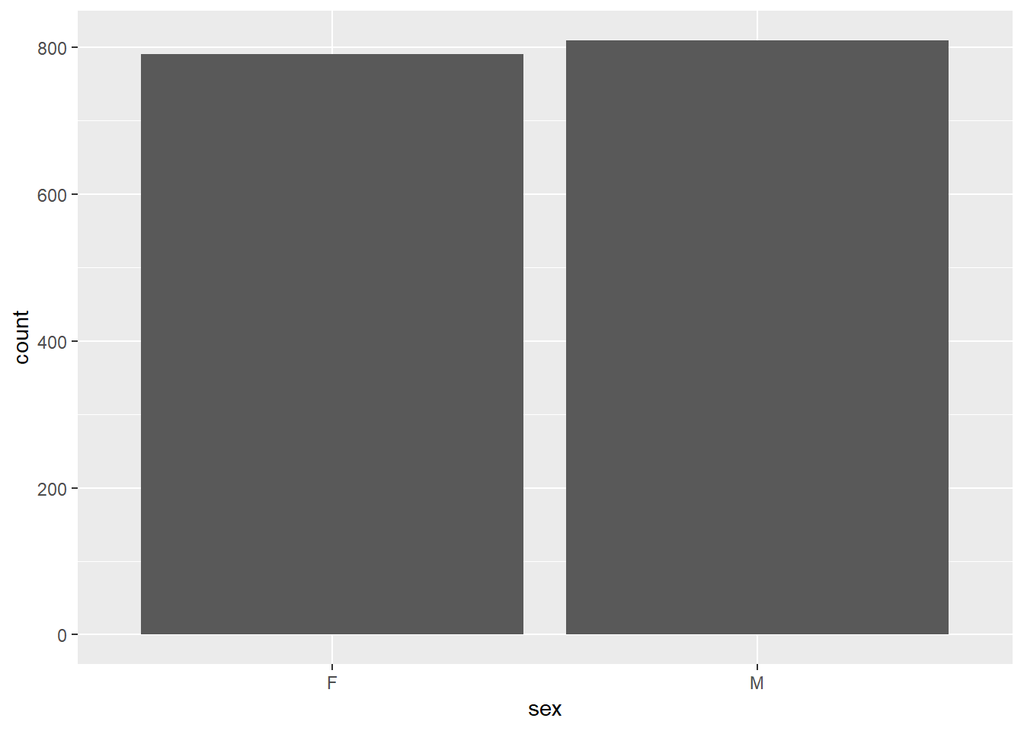

```r
ggplot() +
  geom_bar(data=raw_data, aes(x=sex))
```

#### Introducing ggplot - aesthetics

Change the colour in aesthetics

```r
ggplot() +
  geom_bar(data=raw_data, aes(x=sex, fill = "red"))
```

#### Introducing ggplot - aesthetics

Change the colour in aesthetics by variable

```r
ggplot() +
  geom_bar(data=raw_data, aes(x=sex, fill = sex))
```

#### Additional features

Adding **labels**, **titles**, and **themes**

```r
ggplot() +
  geom_bar(data=raw_data, aes(x=sex, fill=sex))+
  xlab("Sex") + # Label for the X axis
  ylab("Cases") + # Label for the Y axis
  ggtitle("Disease cases by Sex") + #Title
  theme_classic() # Plot theme for background etc.
```

#### 1.3.1 Create a barplot of species

Create a barplot of species and colour by species.

```r
ggplot() +
  geom_bar(data=raw_data, aes(x=________, fill = ________)) +
  theme_classic()
```

#### 1.3.2 Add a title and some labels to the barplot of species

```r
ggplot() +
  geom_bar(data=raw_data, aes(x=________, fill = ________)) +
  _________ +
  _________ +
  _________ +
  theme_classic()
```